# intro to viz

Charles Lang

September 26, 2019

#Input

```r
D1 <- read.csv("School_Demographics_and_Accountability_Snapshot_2006-2012.csv", header = TRUE, sep = ",")

#Create a data frame only contains the years 2011-2012
library(dplyr)
D2 <- filter(D1, schoolyear == 20112012)
```

#Histograms

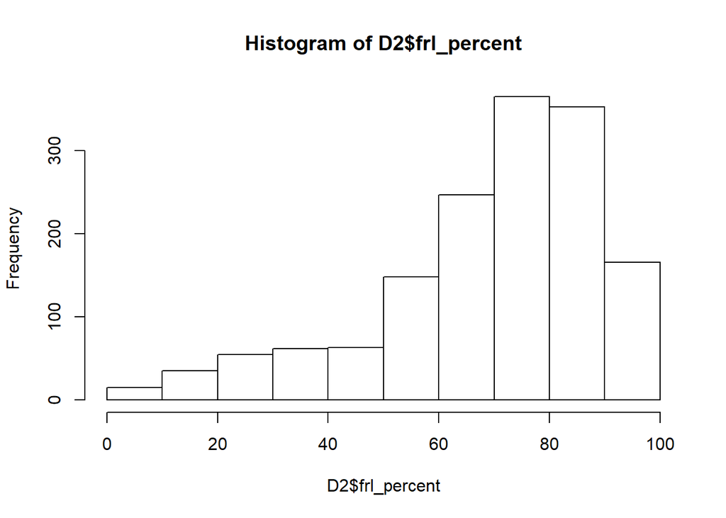

```r
#Generate a histogram of the percentage of free/reduced lunch students (frl_percent) at each school

hist(D2$frl_percent)
```

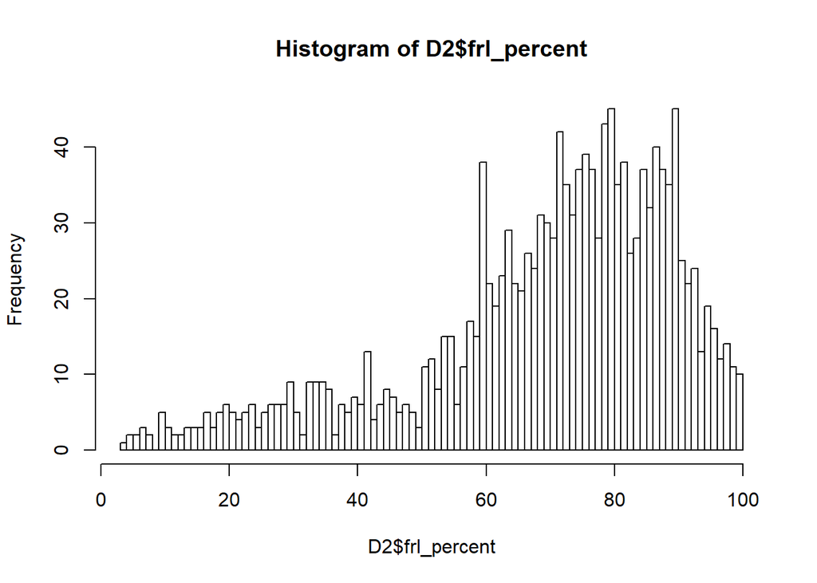

```r
#Change the number of breaks to 100, do you get the same impression?

hist(D2$frl_percent, breaks = 100)
```

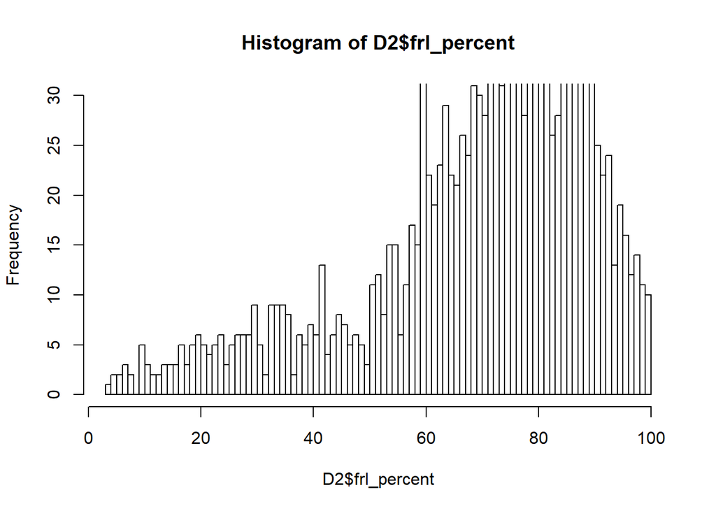

```r
#Yes. Both histograms show negative skew with most data around 80% of students with free/reduced lunch.

#Cut the y-axis off at 30

hist(D2$frl_percent, breaks = 100, ylim = c(0,30))
```

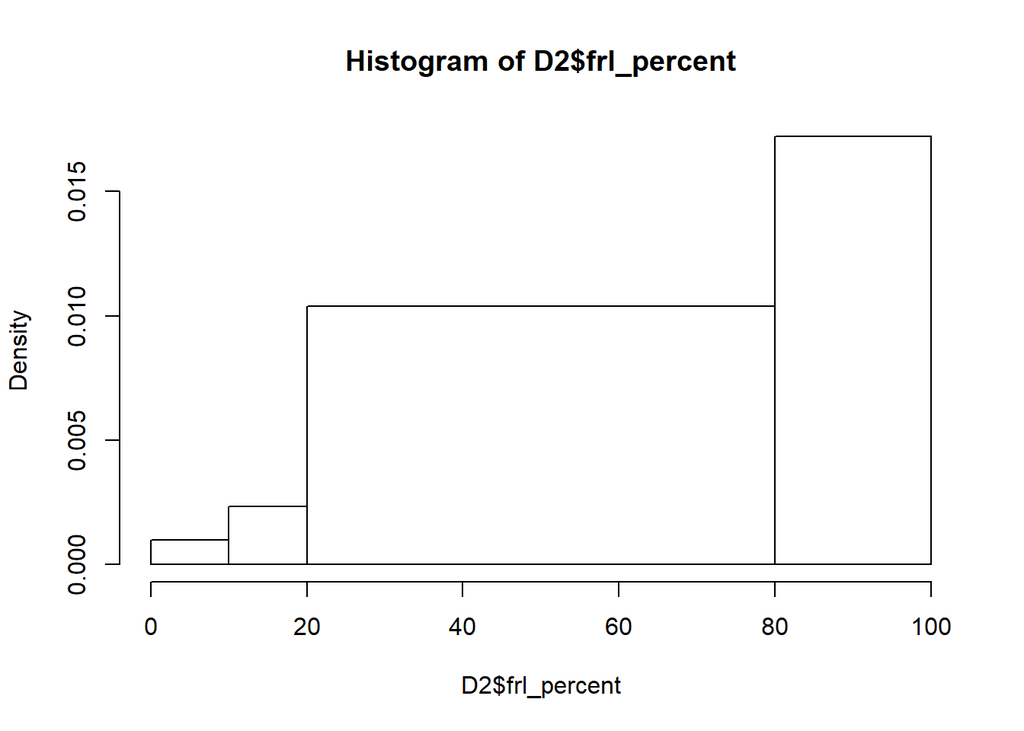

```r
#Restore the y-axis and change the breaks so that they are 0-10, 10-20, 20-80, 80-100

hist(D2$frl_percent, breaks = c(0,10,20,80,100))
```

#Plots

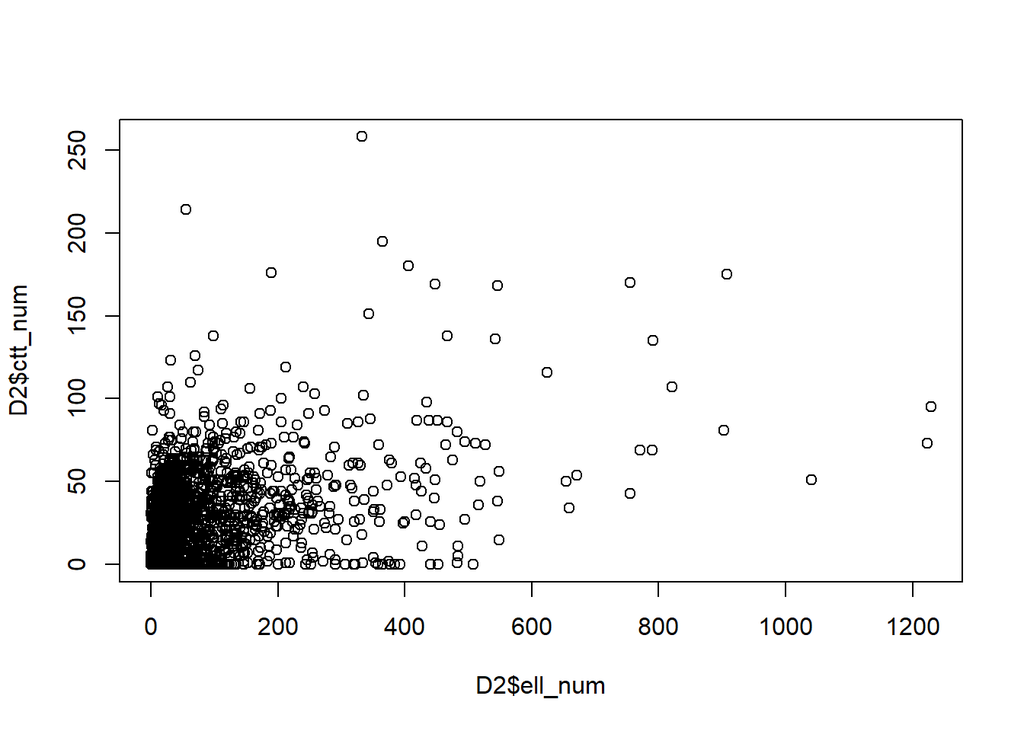

```r
#Plot the number of English language learners (ell_num) by Computational Thinking Test scores (ctt_num)

plot(D2$ell_num, D2$ctt_num)
```

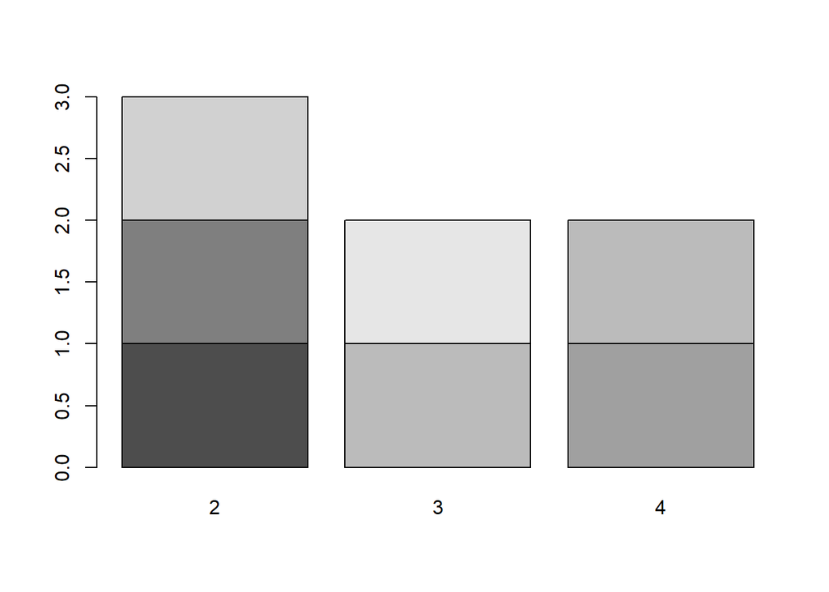

```r
#Create two variables x & y
x <- c(1,3,2,7,6,4,4)
y <- c(2,4,2,3,2,4,3)

#Create a table from x & y
table1 <- table(x,y)

#Display the table as a Barplot
barplot(table1)
```

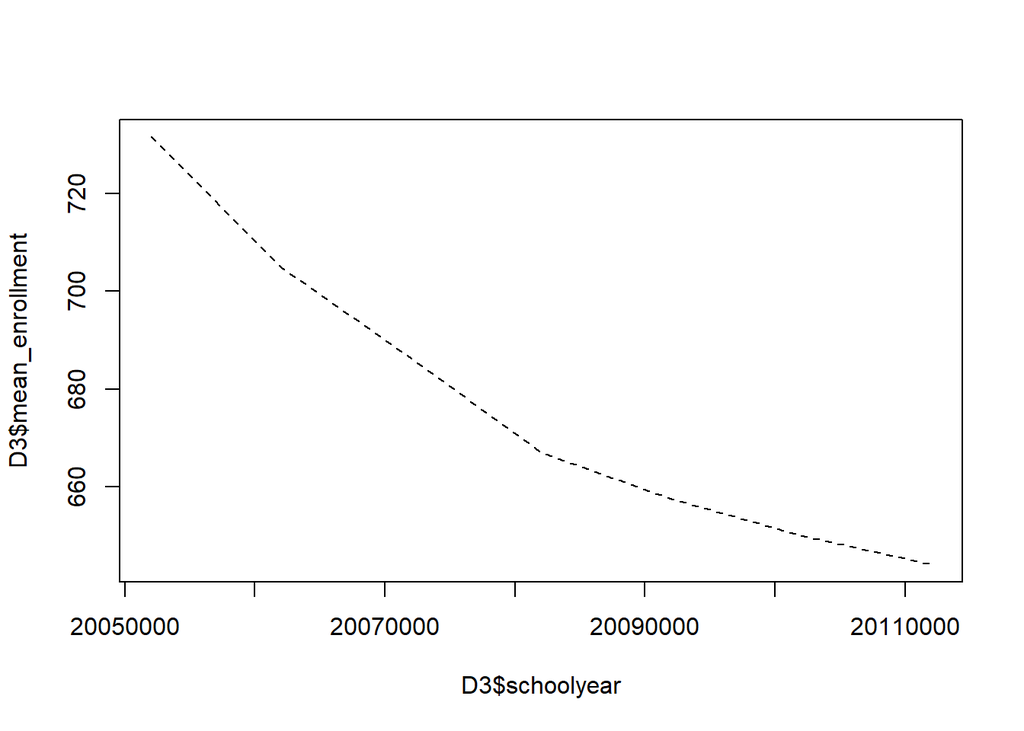

```r
#Create a data frame of the average total enrollment for each year and plot the two against each other as a lines

library(tidyr)
D3 <- D1 %>% group_by(schoolyear) %>% summarise(mean_enrollment = mean(total_enrollment))

plot(D3$schoolyear, D3$mean_enrollment, type = "l", lty = "dashed")
```

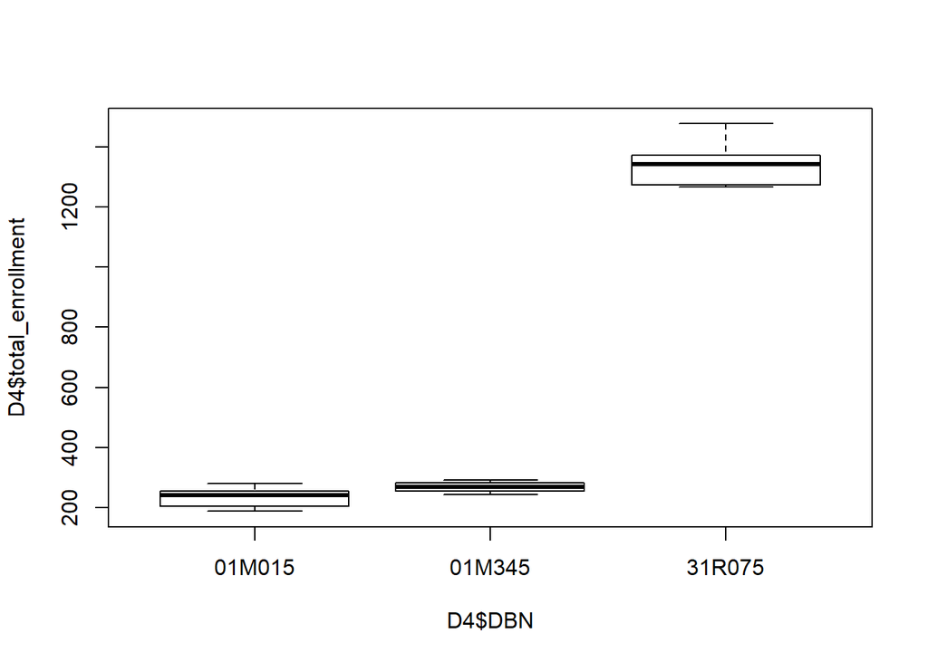

```r
#Create a boxplot of total enrollment for three schools
D4 <- filter(D1, DBN == "31R075"|DBN == "01M015"| DBN == "01M345")
#The drop levels command will remove all the schools from the variable with not data
D4 <- droplevels(D4)
boxplot(D4$total_enrollment ~ D4$DBN)
```

#Pairs

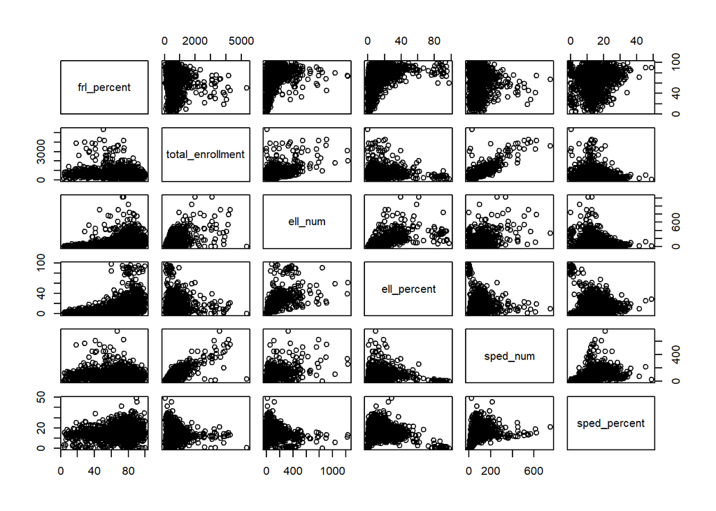

```r
#Use matrix notation to select columns 5,6, 21, 22, 23, 24
D5 <- D2[,c(5,6, 21:24)]
#Draw a matrix of plots for every combination of variables
pairs(D5)
```

# Exercise

1. Create a simulated data set containing 100 students, each with a score from 1-100 representing performance in an educational game. The scores should tend to cluster around 75. Also, each student should be given a classification that reflects one of four interest groups: sport, music, nature, literature.

```r
#rnorm(100, 75, 15) creates a random sample with a mean of 75 and standard deviation of 15
#pmax sets a maximum value, pmin sets a minimum value
#round rounds numbers to whole number values
#sample draws a random samples from the groups vector according to a uniform distribution
studentPerformance = rnorm(100, 75, 15)
studentPerformance[studentPerformance > 100] = 100
studentPerformance[studentPerformance < 1] = 1
studentPerformance = round(studentPerformance)
studentInterest = sample(c("sport", "music", "nature", "literature"), size = 100, replace = TRUE)
studentData = data.frame(id = c(1:100), studentPerformance, studentInterest)
```

2. Using base R commands, draw a histogram of the scores. Change the breaks in your histogram until you think they best represent your data.

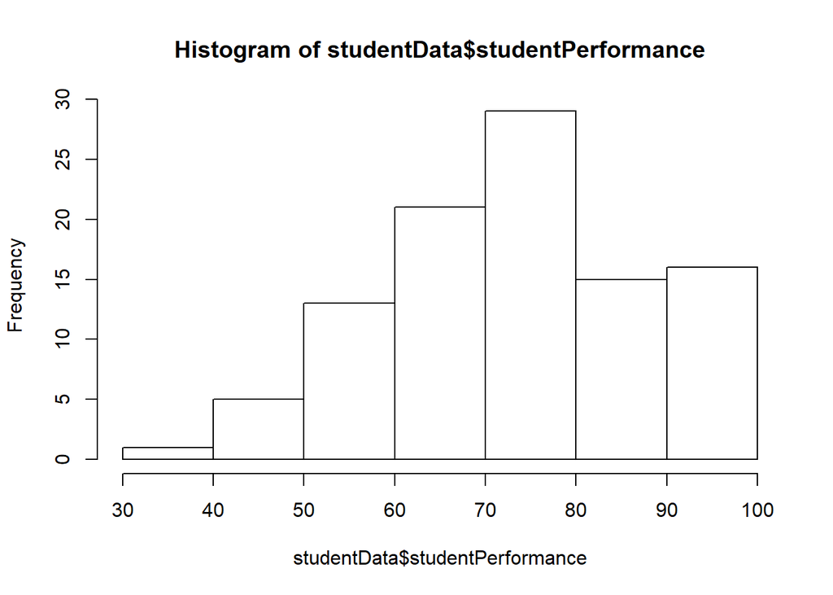

```r
hist(studentData$studentPerformance, breaks = 8)
```

3. Create a new variable that groups the scores according to the breaks in your histogram.

```r
#cut() divides the range of scores into intervals and codes the values in scores according to which interval they fall. We use a vector called `letters` as the labels, `letters` is a vector made up of the letters of the alphabet.
letters = c("F", "E", "D", "C", "B", "A")
studentGrade = cut(studentData$studentPerformance,
                  breaks = c(40, 50, 60, 70, 80, 90, 100),
                  labels = letters)
studentData = cbind(studentData, studentGrade)
```

4. Now using the colorbrewer package (RColorBrewer; http://colorbrewer2.org/#type=sequential&scheme=BuGn&n=3) design a pallette and assign it to the groups in your data on the histogram.

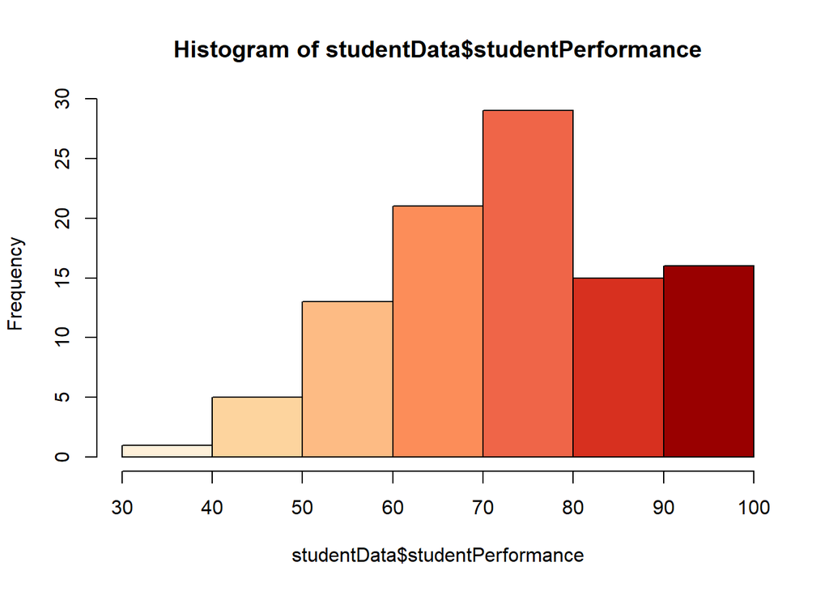

```r
library(RColorBrewer)
#Let's look at the available palettes in RColorBrewer

#The top section of palettes are sequential, the middle section are qualitative, and the lower section are diverging.
#Make RColorBrewer palette available to R and assign to your bins
histColourPalette = brewer.pal(7, "OrRd")

#Use named palette in histogram
hist(studentData$studentPerformance, breaks = 8, col = histColourPalette)
```

[output not shown]

5. Create a boxplot that visualizes the scores for each interest group and color each interest group a different color.

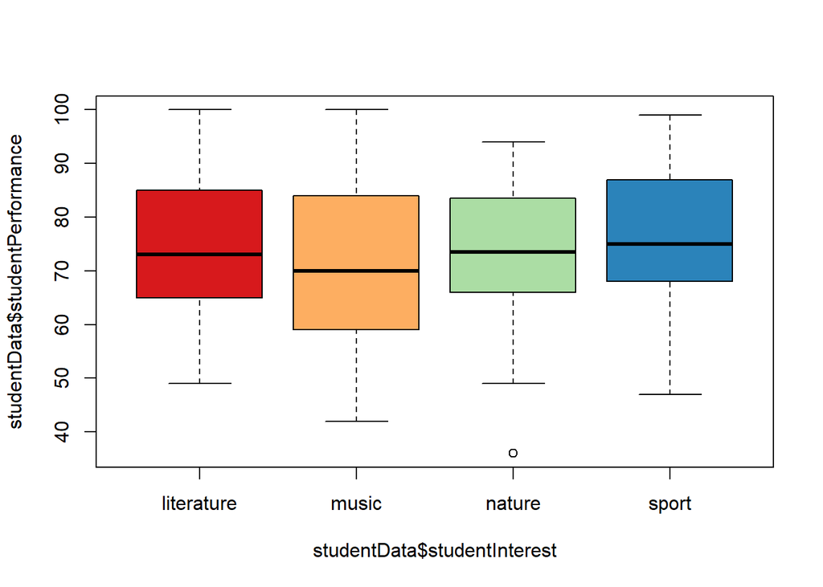

```r
#Make a vector of the colors from RColorBrewer
boxColourPalette = brewer.pal(4, "Spectral")
boxplot(studentData$studentPerformance ~ studentData$studentInterest, col = boxColourPalette)
```

6. Now simulate a new variable that describes the number of logins that students made to the educational game. They should vary from 1-25.

```r
logins = sample(c(1:25), size = 100, replace = TRUE)
studentData = cbind(studentData, logins)
```